# Predator Prey Stability

```r
stability <- stability_measure(res1)
print(paste("The system is stable: ", stability))
```

```
## [1] "The system is stable:  FALSE"
```

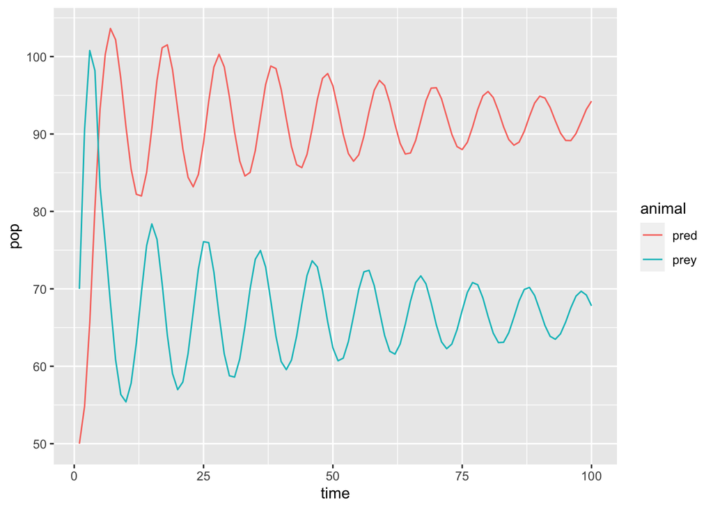

```r
# set parameter list
pars = data.frame(rprey=0.95, alpha=0.01, eff=0.6,pmort=0.4, K=2000, hunt_level = 0.20, min_prey_pop = 80)
# times when you want to evaluate
days = seq(from=1,to=100)
res = ode(func=lotvmodK, y=currpop, times=days, parms=pars)
res2 = as.data.frame(res) %>% gather(key="animal", value="pop",-time)
p2 = ggplot(res2, aes(time, pop, col=animal))+geom_line()
p2
```

```r
stability <- stability_measure(res2)
print(paste("The system is stable: ", stability))
```

```
## [1] "The system is stable:  FALSE"
```

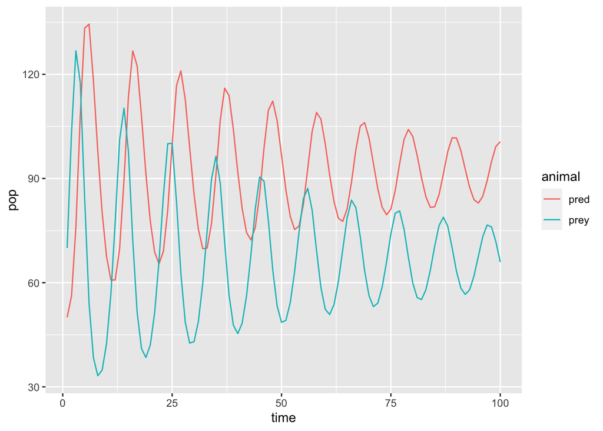

```r
# set parameter list
pars = data.frame(rprey=0.95, alpha=0.01, eff=0.6,pmort=0.4, K=2000, hunt_level = 0.05, min_prey_pop = 110)
# times when you want to evaluate
days = seq(from=1,to=100)
res = ode(func=lotvmodK, y=currpop, times=days, parms=pars)
res3 = as.data.frame(res) %>% gather(key="animal", value="pop",-time)
p2 = ggplot(res3, aes(time, pop, col=animal))+geom_line()
p2
```

```r
stability <- stability_measure(res3)
print(paste("The system is stable: ", stability))
```

```
## [1] "The system is stable:  TRUE"
```

**Recommended Hunting Strategy**

*To bring our system back to stability (or double our predator population) we recommend that the hunting level doesn’t exceed 5%, bearing in mind that you should let the prey population grow to a population of 110 before you let hunting begin. This is necessary because we need their to be abundant prey for the predators to eat to then grow their population*